# PS5: Intro to `ggplot2`

### 1.1.4 Adding smoothers

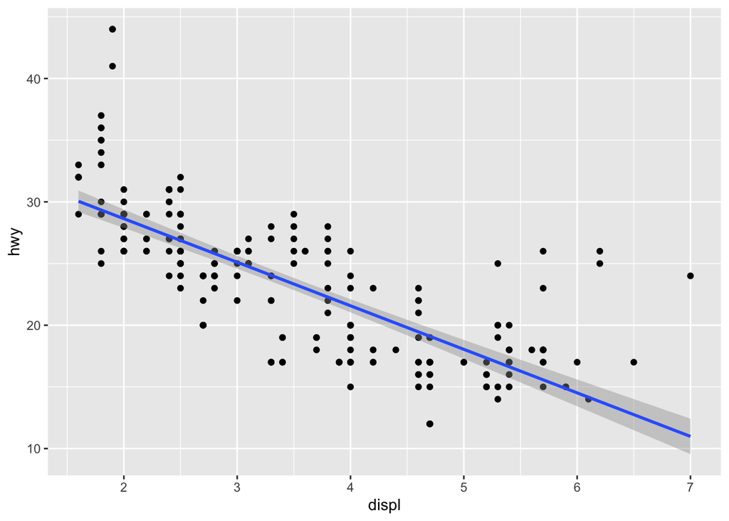

```r
ggplot(data = mpg, aes(x = displ, y = hwy)) +
  geom_point() +
  geom_smooth(method = 'lm')
```

`geom_smooth()` with the argument `method = 'lm'` plots a least squares regression line for highway mileage on engine displacement. The translucent gray band is a confidence interval for the predictions of mileage.

Modify the code above by adding a vertical line at $x=4$ using `geom_vline()`. Does it require `aes()`?

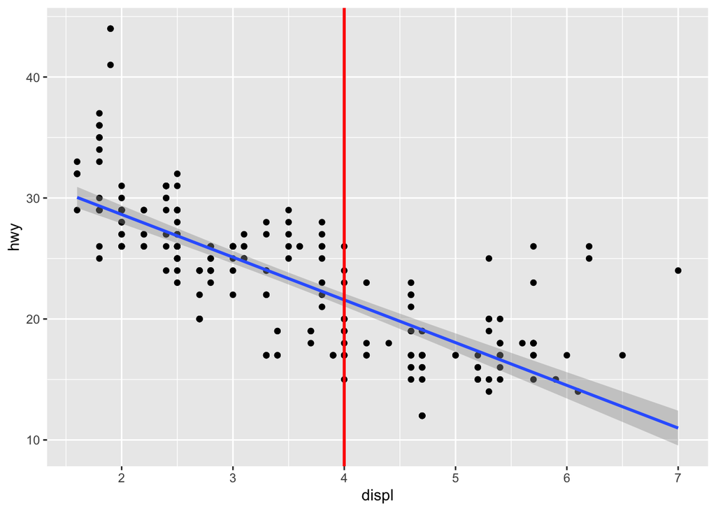

```r
# your code here
ggplot(data = mpg, aes(x = displ, y = hwy)) +
  geom_point() +
  geom_smooth(method = 'lm') +
  geom_vline(xintercept = 4, color = "red", size = 1)
```

Now try adding a vertical line at the mean of `displ`. Does it require `aes()` this time?

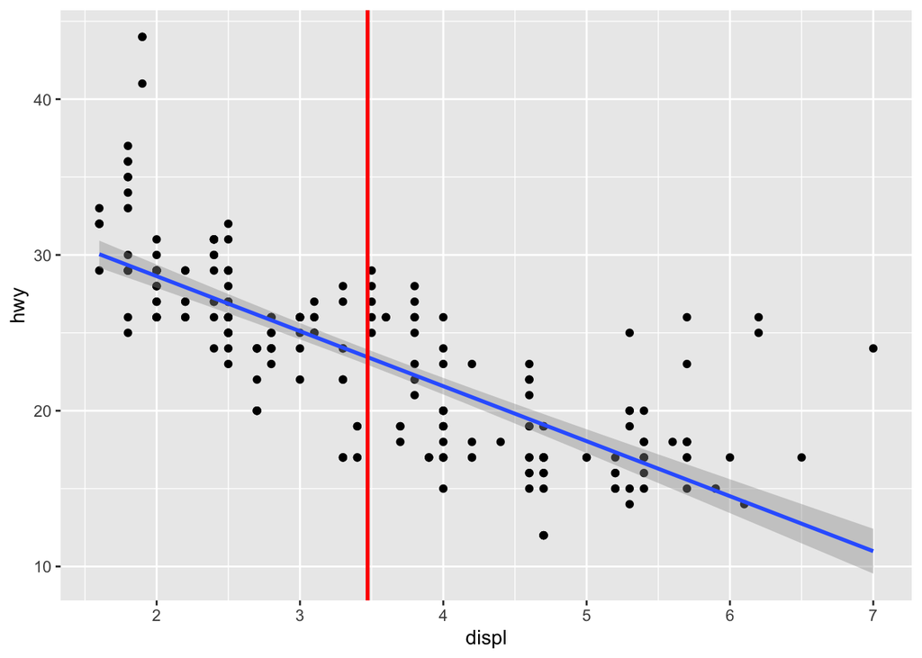

```r
# your code here
ggplot(data = mpg, aes(x = displ, y = hwy)) +
  geom_point() +
  geom_smooth(method = 'lm') +
  geom_vline(xintercept = mean(mpg$displ), color = "red", linewidth = 1)
```

Do the same with a horizontal line at the mean of `hwy`. Play around with color and size. Should those arguments go inside or outside of `aes()`?

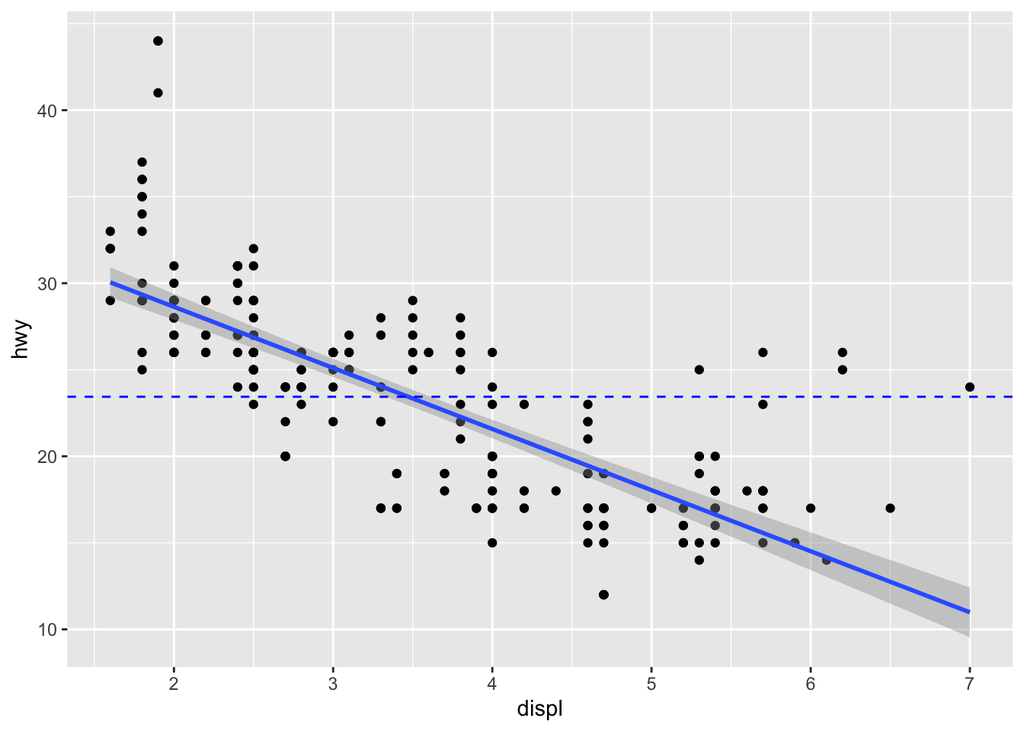

```r
# your code here
ggplot(data = mpg, aes(x = displ, y = hwy)) +
  geom_point() +
  geom_smooth(method = 'lm') +
  geom_hline(yintercept = mean(mpg$hwy), color = "blue", linetype = "dashed")
```

### 1.1.5 Using facets

Let’s return to the basic scatter plot again.

```r
ggplot(data = mpg, aes(x = displ, y = hwy)) +
  geom_point()
```

[output not shown]

There are only two unique values for `year`, 1999 and 2008. Let’s compare the relationship between `hwy` and `displ` between years using `facet_wrap()`.

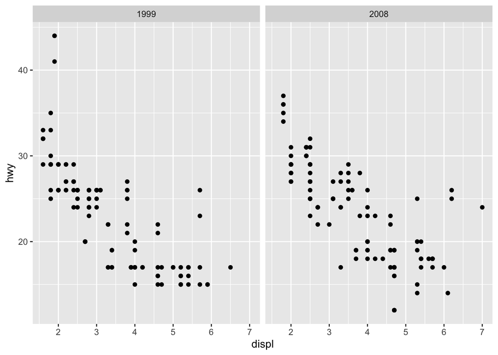

```r
ggplot(data = mpg, aes(x = displ, y = hwy)) +
  geom_point() +
  facet_wrap(~ year)
```

What happens when you facet (essentially, compare) using a different variable? Modify the code above and try.

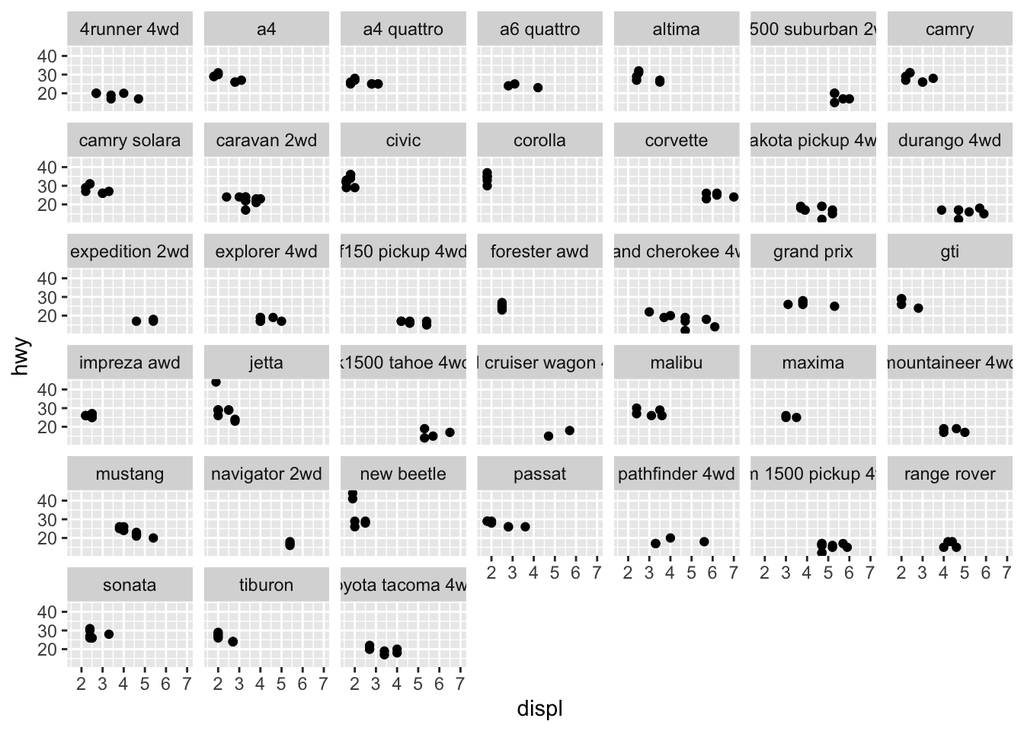

```r
# your code here
ggplot(data = mpg, aes(x = displ, y = hwy)) +
  geom_point() +
  facet_wrap(~ model)
```

`facet_grid()` works slightly differently from `facet_wrap()`. The latter takes in only one variable, which always goes after the `~`, and it ‘wraps’ the plots left to right, top to bottom. `facet_grid()` allows you to facet into just rows or just columns

Here’s an example to create facets by columns:

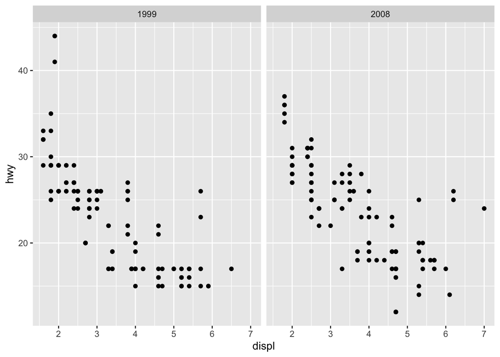

```r
# facet into columns
ggplot(data = mpg, aes(x = displ, y = hwy)) +
  geom_point() +
  facet_grid(. ~ year)
```

```r
# facet into columns (equivalent command)
ggplot(data = mpg, aes(x = displ, y = hwy)) +
  geom_point() +
  facet_grid(cols = vars(year))
```

Here’s an example to create facets by rows:

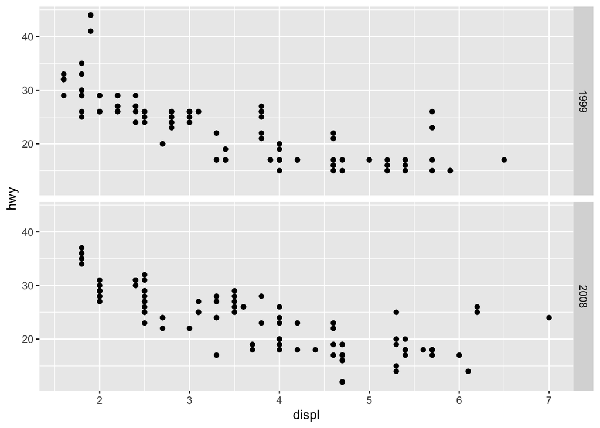

```r
# facet into rows
ggplot(data = mpg, aes(x = displ, y = hwy)) +
  geom_point() +
  facet_grid(year ~ .)
```

```r
# facet into columns (equivalent command)
ggplot(data = mpg, aes(x = displ, y = hwy)) +
  geom_point() +
  facet_grid(rows = vars(year))
```

The `.` is a placeholder for a variable. Modify either code chunk above by replacing the `.` with another variable, such as `cyl`. How does the display change?

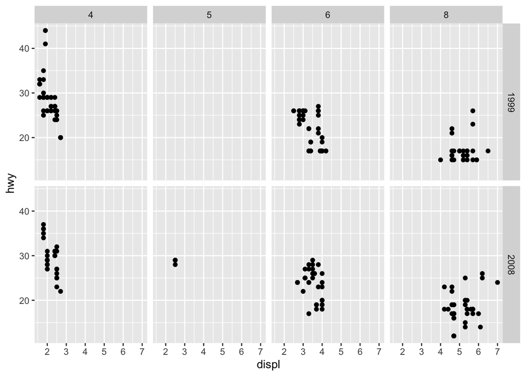

```r
# your code here
ggplot(data = mpg, aes(x = displ, y = hwy)) +
  geom_point() +
  facet_grid(year ~ cyl)
```

### 1.1.6 More `facet_grid()`

Interestingly, we can use `facet_grid()` to “double facet” into rows and columns by providing two *faceting* variables:

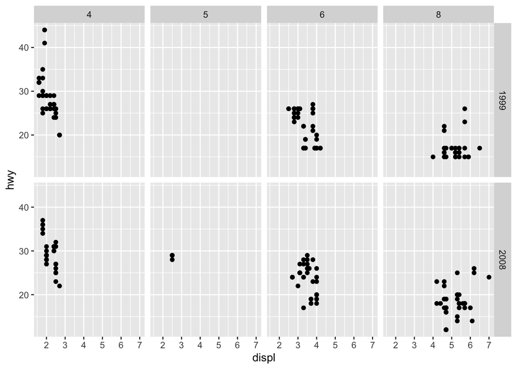

```r
# facet into rows and columns
# rows: based on year
# columns: based on cyl
ggplot(data = mpg, aes(x = displ, y = hwy)) +
  geom_point() +
  facet_grid(year ~ cyl)
```

### 1.1.7 More facets

Finally, let’s study just the distribution of highway mileage.

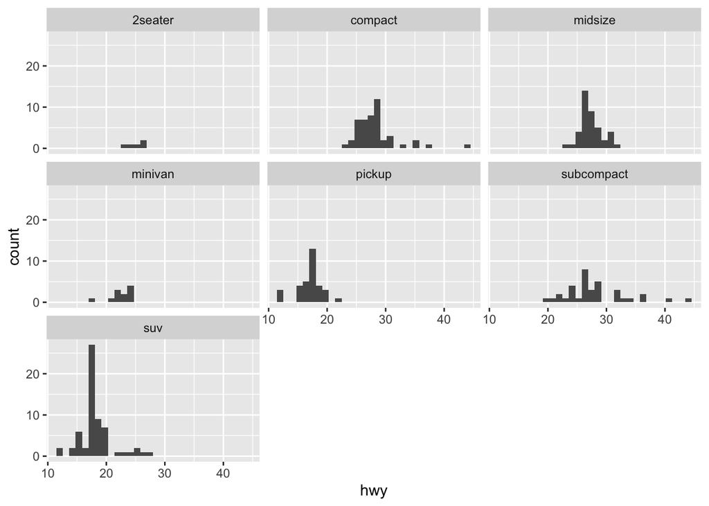

```r
ggplot(data = mpg) +
  geom_histogram(aes(x = hwy)) +
  facet_wrap(~ class)
```

Instead of using a histogram to study the distribution, let’s try a boxplot instead.

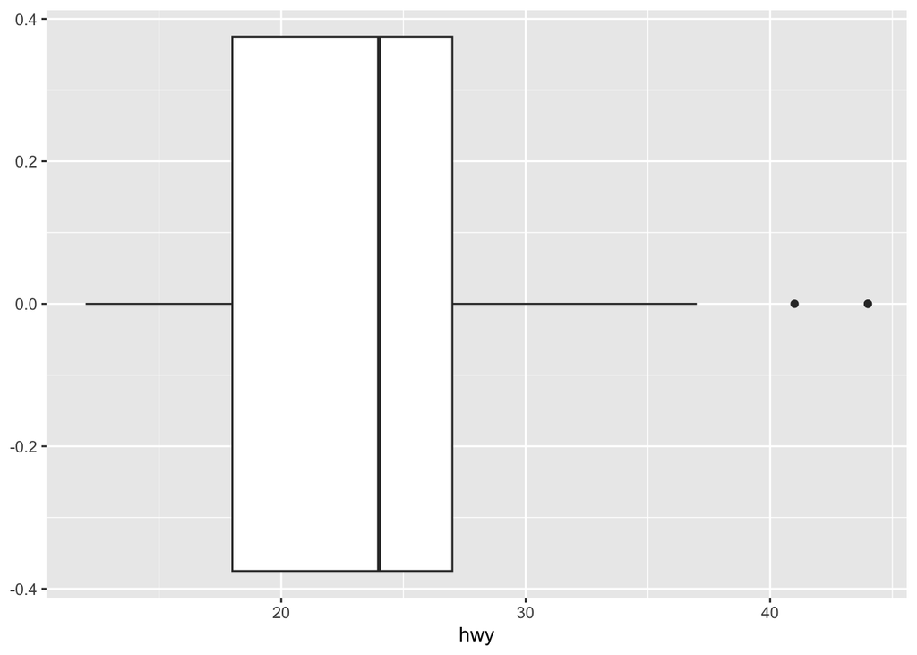

```r
ggplot(data = mpg) +
  geom_boxplot(aes(x = hwy))
```

Notice that `geom_histogram()` and `geom_boxplot()` required only an `x` aesthetic. What happens if you replace `x` with `y`?

Facet again by modifying the code above, this time using any variable of your choice.

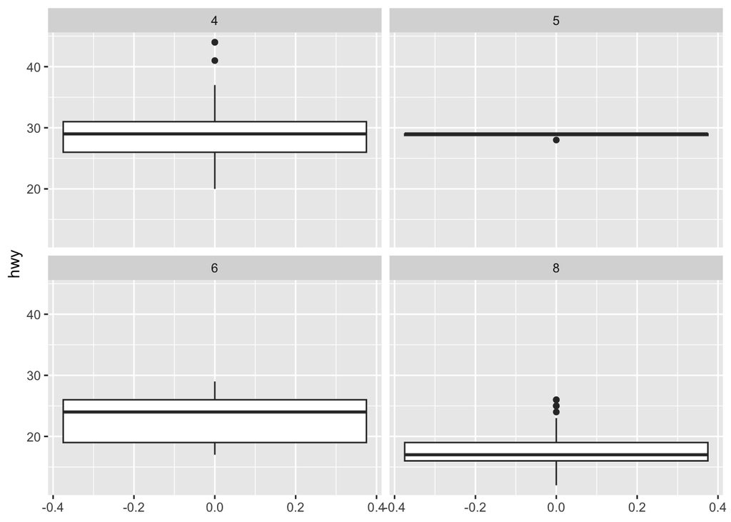

```r
# your code here
ggplot(data = mpg) +
  geom_boxplot(aes(y = hwy)) +
  facet_wrap(~ cyl)
```

# 2 Iris Dataset

We are going to use the famous `iris` data set which is a built-in data frame in R. This data set contains petal and sepal measurements of iris flowers from three different species (see image below).

[figure not shown]

It even has its own Wikipedia page: [*Iris* flower data set](https://en.wikipedia.org/wiki/Iris_flower_data_set).

```r
head(iris, n = 5)
```

```
  Sepal.Length Sepal.Width Petal.Length Petal.Width Species
1          5.1         3.5          1.4         0.2  setosa
2          4.9         3.0          1.4         0.2  setosa
3          4.7         3.2          1.3         0.2  setosa
4          4.6         3.1          1.5         0.2  setosa
5          5.0         3.6          1.4         0.2  setosa
```

While we can access this dataset in R, we are going to use it to practice loading in a dataset. Go to the page on bcourses for this assignment and download the data files `iris.csv` and `iris.txt` present in the instructions: [Problem Set 5](https://bcourses.berkeley.edu/courses/1551809/assignments/9021598). Place them in the directory with your qmd and html files.

## 2.1 Reading in Data

Open up each data file and identify the way it is stored: e.g. comma-separated, fixed width, etc.

1. Using `readr` functions, read in `iris.csv` and asign it to the variable `iris_a`.

```r
library(readr)
iris_a <- read_csv("iris.csv")
```

Check using `head()` that the dataframe `iris_a` that you just made matches the one shown at the beginning of the assignment.

```r
# your code here
head(iris_a)
```

```
# A tibble: 6 × 5
  Sepal.Length Sepal.Width Petal.Length Petal.Width Species
         <dbl>       <dbl>        <dbl>       <dbl> <chr>
1          5.1         3.5          1.4         0.2 setosa
2          4.9         3            1.4         0.2 setosa
3          4.7         3.2          1.3         0.2 setosa
4          4.6         3.1          1.5         0.2 setosa
5          5           3.6          1.4         0.2 setosa
6          5.4         3.9          1.7         0.4 setosa
```

2. Using `readr` functions, read in `iris.txt` and asign it to the variable `iris_b`.

```r
# your code here
iris_b <- read_csv("iris.txt")
```

Check using `head()` that the dataframe `iris_b` that you just made matches the one shown at the beginning of the assignment.

```r
# your code here
head(iris_b)
```

```
# A tibble: 6 × 1
  `Sepal.Length Sepal.Width Petal.Length Petal.Width Species`
  <chr>
1 5.1 3.5 1.4 0.2 setosa
2 4.9 3 1.4 0.2 setosa
3 4.7 3.2 1.3 0.2 setosa
4 4.6 3.1 1.5 0.2 setosa
5 5 3.6 1.4 0.2 setosa
6 5.4 3.9 1.7 0.4 setosa
```

## 2.2 Mappings and Geometries

Fill in the code chunks and write commands to obtain the following graphics. The first one has been completed for you.

1. Histogram of `Sepal.Length`

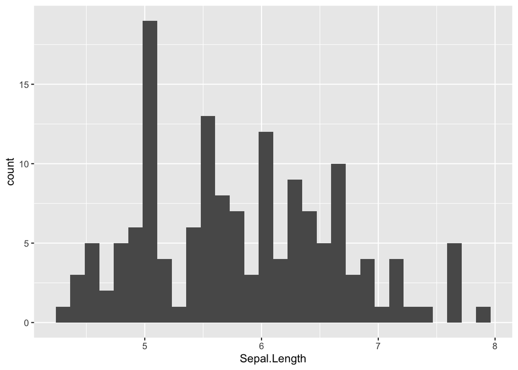

```r
ggplot(data = iris, mapping = aes(x = Sepal.Length)) + geom_histogram()
```

2. Density plot of `Sepal.Length`

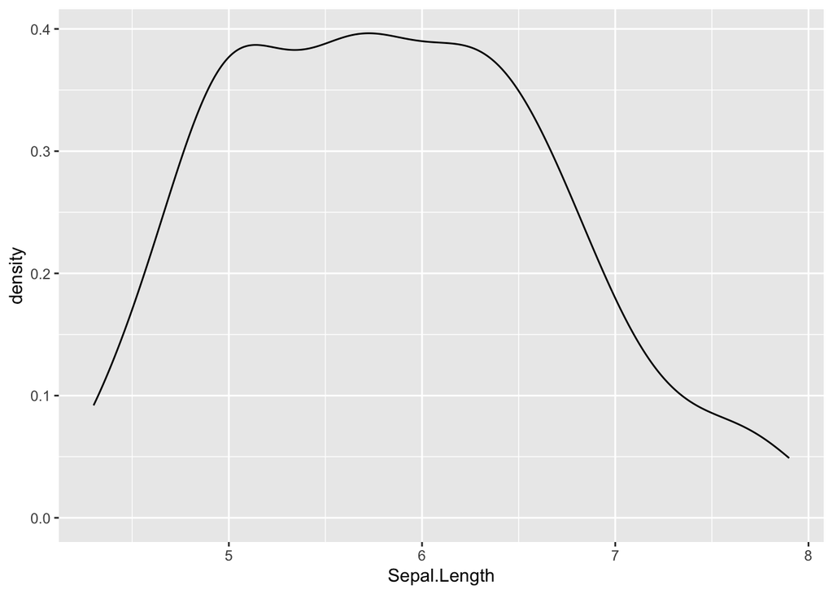

```r
# your code here
ggplot(data = iris, mapping = aes(x = Sepal.Length)) + geom_density()
```

3. Violin plot of `Sepal.Length`

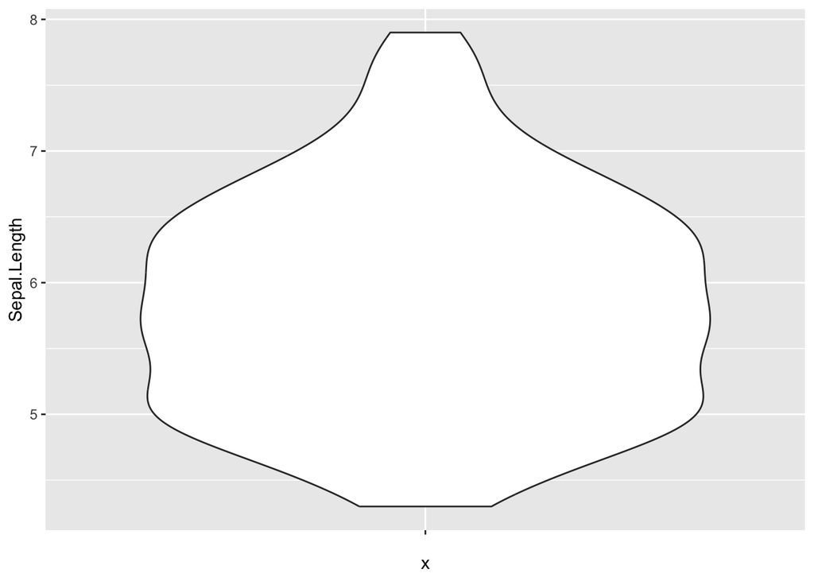

```r
# your code here
ggplot(data = iris, mapping = aes(x = "", y = Sepal.Length)) + geom_violin()
```

4. Scatter plot of `Sepal.Length` (x) and `Sepal.Width` (y)